# Basic Example

Ruben Cabrera

2024-07-29

# Basic Example

Adding Covariances between random effects https://nlmixr2.org/articles/addingCovariances.html

```r
library(nlmixr2)
library(ggplot2)
library(ggforce) # facet_wrap_paginate
library(dplyr) # For filter
```

## Data

Phenobarbitol data:

- ID: Infant ID
- TIME: Time of (hr)
- AMT: Dose in (ug/kg)
- WT: Weight (kg)
- APGR: A 5-minute Apgar score to measure infant health
- DV: The concentration of phenobarbitol in the serum (ug/mL)
- MDV: If the dependent variable (DV) is missing; 0 for observations, 1 for doses
- EVID: Event ID

```r
# ?pheno_sd
head(pheno_sd)
```

```
##   ID TIME  AMT  WT APGR   DV MDV EVID      NWE
## 1  1  0.0 25.0 1.4    7  0.0   1    1 1.076923
## 2  1  2.0  0.0 1.4    7 17.3   0    0 1.076923
## 3  1 12.5  3.5 1.4    7  0.0   1    1 1.076923
## 4  1 24.5  3.5 1.4    7  0.0   1    1 1.076923
## 5  1 37.0  3.5 1.4    7  0.0   1    1 1.076923
## 6  1 48.0  3.5 1.4    7  0.0   1    1 1.076923
```

```r
summary(pheno_sd)
```

```
##        ID             TIME             AMT               WT
##  Min.   : 1.00   Min.   :  0.00   Min.   : 0.000   Min.   :0.60
##  1st Qu.:13.00   1st Qu.: 19.23   1st Qu.: 2.300   1st Qu.:1.10
##  Median :25.00   Median : 59.30   Median : 3.000   Median :1.30
##  Mean   :28.24   Mean   : 63.70   Mean   : 5.281   Mean   :1.49
##  3rd Qu.:44.00   3rd Qu.: 96.42   3rd Qu.: 4.400   3rd Qu.:1.70
##  Max.   :59.00   Max.   :389.80   Max.   :70.000   Max.   :3.60
##       APGR              DV              MDV              EVID
##  Min.   : 1.000   Min.   : 0.000   Min.   :0.0000   Min.   :0.0000
##  1st Qu.: 5.000   1st Qu.: 0.000   1st Qu.:1.0000   1st Qu.:1.0000
##  Median : 7.000   Median : 0.000   Median :1.0000   Median :1.0000
##  Mean   : 6.394   Mean   : 5.328   Mean   :0.7917   Mean   :0.7917
##  3rd Qu.: 8.000   3rd Qu.: 0.000   3rd Qu.:1.0000   3rd Qu.:1.0000
##  Max.   :10.000   Max.   :67.900   Max.   :1.0000   Max.   :1.0000
##       NWE
##  Min.   :0.4615
##  1st Qu.:0.8462
##  Median :1.0000
##  Mean   :1.1464
##  3rd Qu.:1.3077
##  Max.   :2.7692
```

```r
str(pheno_sd)
```

```
## 'data.frame':    744 obs. of  9 variables:
##  $ ID  : int  1 1 1 1 1 1 1 1 1 1 ...
##  $ TIME: num  0 2 12.5 24.5 37 48 60.5 72.5 85.3 96.5 ...
##  $ AMT : num  25 0 3.5 3.5 3.5 3.5 3.5 3.5 3.5 3.5 ...
##  $ WT  : num  1.4 1.4 1.4 1.4 1.4 1.4 1.4 1.4 1.4 1.4 ...
##  $ APGR: int  7 7 7 7 7 7 7 7 7 7 ...
##  $ DV  : num  0 17.3 0 0 0 0 0 0 0 0 ...
##  $ MDV : int  1 0 1 1 1 1 1 1 1 1 ...
##  $ EVID: int  1 0 1 1 1 1 1 1 1 1 ...
##  $ NWE : num  1.08 1.08 1.08 1.08 1.08 ...
```

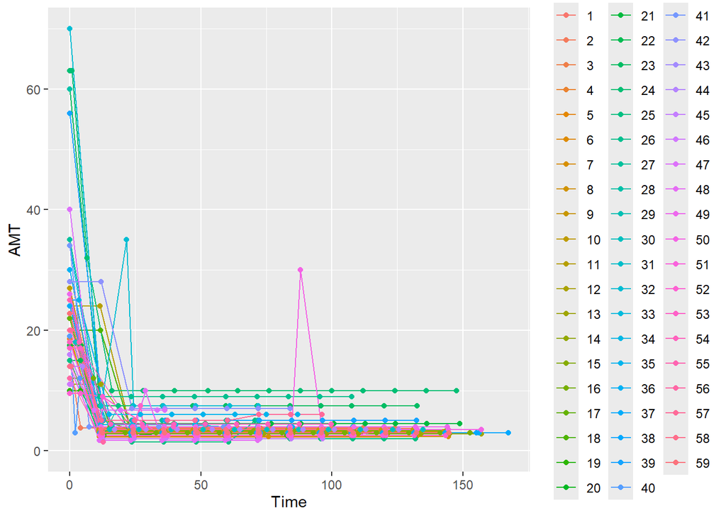

```r
# Plot data AMT Dose in (ug/kg)
ggplot(filter(pheno_sd,EVID==1), aes(x=TIME, y = AMT, group=factor(ID), color=factor(ID))) + geom_line() + geom_point() + ylim(c(0, 70)) + xlab('Time')
```

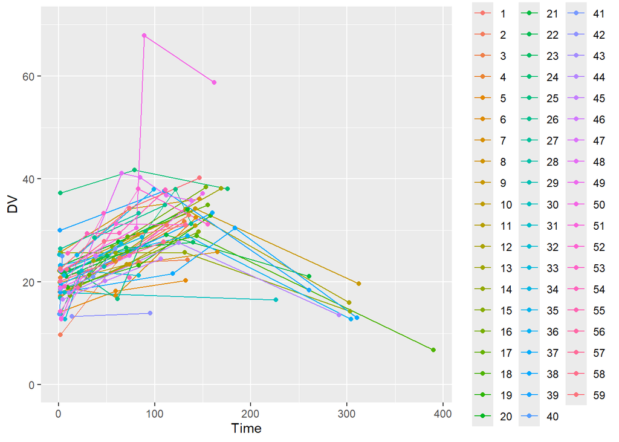

```r
## Plot data DV concentration of phenobarbitol

ggplot(filter(pheno_sd,EVID==0), aes(x=TIME, y = DV, group=factor(ID), color=factor(ID))) + geom_line() + geom_point() + ylim(c(0, 70)) + xlab('Time')
```

```r
# Could be interesting plot AMT vs DV (using the last data recorded in both axis)
```

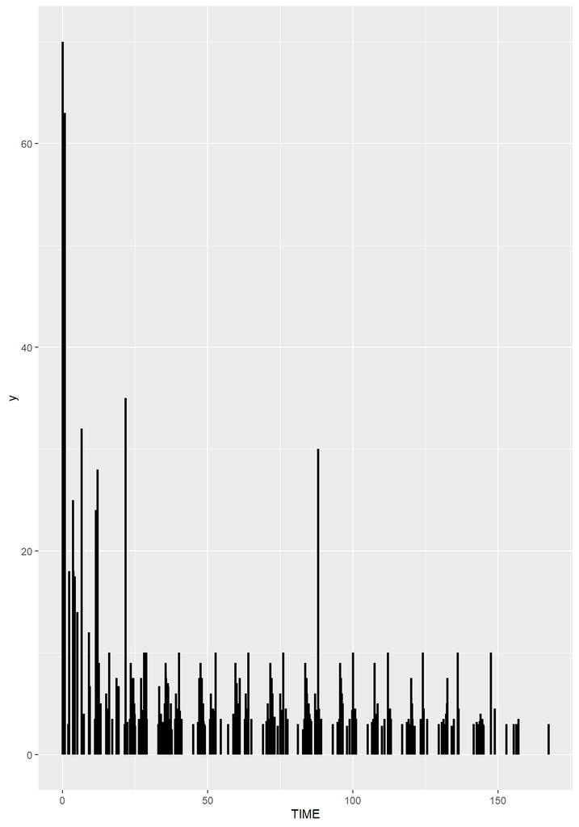

```r
# The superposition of doses as vertical black lines on concentration profiles

pAMT <- geom_segment(data=filter(pheno_sd,EVID==1), aes(x=TIME, xend=TIME, y=0, yend=AMT), size=1)

pDV <- geom_point(data=filter(pheno_sd,EVID==0), aes(x=TIME, y=DV,  color=factor(ID)), size=3)

ggplot() + pAMT
```

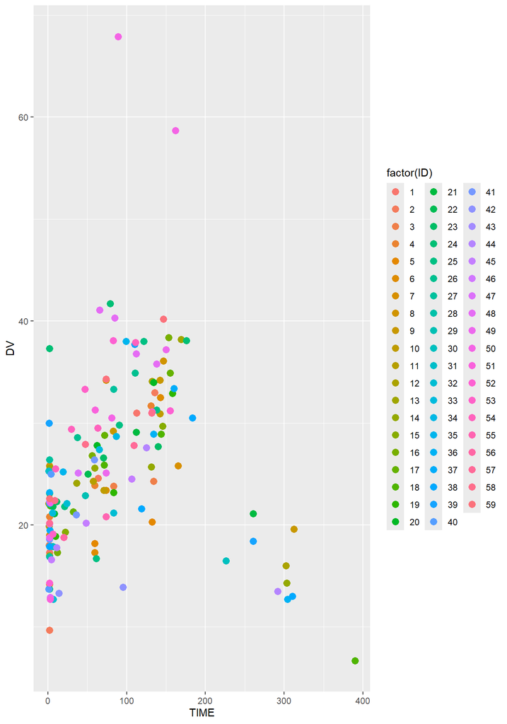

```r
ggplot() + pDV
```

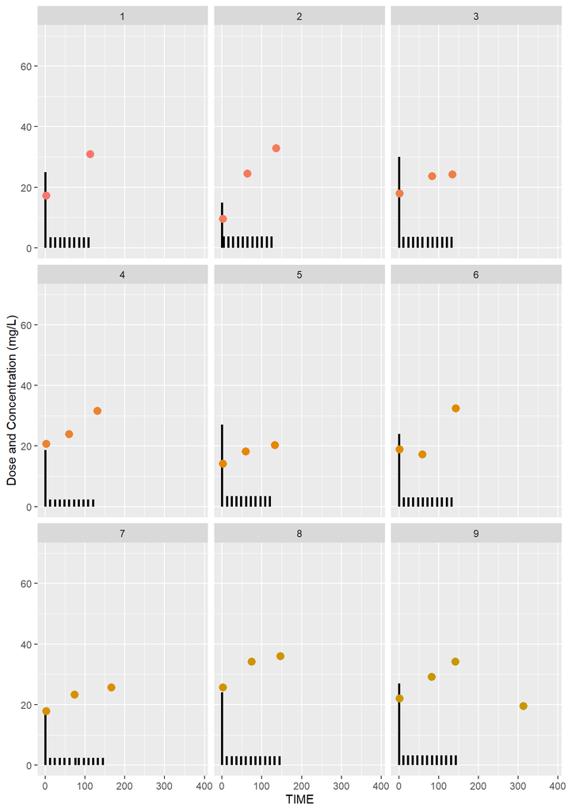

```r
ggplot() + pAMT + pDV + facet_wrap_paginate(ID~., ncol=3, nrow=3, page=1) + theme(legend.position="none") + ylab("Dose and Concentration (mg/L)")
```

# Model

## Compartmental Models

Pharmacokinetics is the study of the time course of a drug and its metabolites following introduction into the body. In this section we describe a class of models that has been extensively used in such studies to model individual drug concentrations, $y(t)$, as a function of the time $t$.

Let $A_i(t)$ represent the amount of drug in compartment $i$, $i=0,1$ at time $t$, with compartment 0 representing the site from which absorption occurs. The differential equations describing the drug flow between the compartments may be assumed to be of the form

$$\frac{d A_0}{d t} = -k_a A_0$$

$$\frac{d A_1}{d t} = k_a A_0 - k_e A_1$$

where $k_a$ is the absorption rate constant associated with flow from compartment 0 to compartment 1, and $k_e$ is the elimination rate constant.

## One Compartment

With only one compartment $A_1$, the differential equation for the amount $A_1$ is

$$\frac{d A_1}{dt } = - k_e A_1$$

The concentration is

$$C_p = \frac{A_1(t)}{V(t)}$$
and considering $V$ as volume, the clearance $ CL $ is defined from

$$k_e = \frac{CL}{V}$$

It is usual to parametrize the model in terms of clearance $CL$ and volume $V$ instead of $k_e$.

The actual fitting parametrization is carried out in term of so called typical values for clearance and volume $tcl$ and $tv$ :

$$\begin{align}
CL =& e^{ tcl + \eta_{CL} } \\
V =& e^{ tv + \eta_{V} }
\end{align}$$
where $\eta_{CL}$ and $\eta_{V}$ are random variables obeying normal distributions with mean zero and covariance matrix $\Omega$. The components of $\Omega$ are then additional fit parameters. The matrix $\Omega$ and the variables $\eta$ are responsible to explain random inter-individual variability.

$$(\eta_{CL} , \eta_{V}) \approx N(0,
\Omega)$$
If $\Omega$ is a diagonal matrix, the inter-individual variabilities are independent. Otherwise, they have some correlation.

The residual error model provides the final random variability on the predicted concentration. The residual error model in this example is

$$C_{obs} = C_p + \varepsilon$$

$$\varepsilon \approx N(0, \sigma^2)$$

```r
pheno <- function() {
  ini({
    tcl <- log(0.008) # typical value of clearance
    tv <-  log(0.6)   # typical value of volume
    eta.cl + eta.v ~ c(1, 0.01, 1) ## var(eta.cl), cov(eta.cl, eta.v), var(eta.v)
                      # interindividual variability on clearance and volume
    add.err <- 0.1    # residual variability
  })
  model({
    cl <- exp(tcl + eta.cl) # individual value of clearance
    v <- exp(tv + eta.v)    # individual value of volume
    ke <- cl / v            # elimination rate constant
    d/dt(A1) = - ke * A1    # model differential equation
    cp = A1 / v             # concentration in plasma
    cp ~ add(add.err)       # define error model
  })
}
```

The fit is performed by the function nlmixr/nlmixr2 specifying the model, data and estimate

```r
fit <- nlmixr(pheno, pheno_sd, "saem", control=list(print=0), table=list(cwres=TRUE, npde=TRUE))
```

```
## ℹ parameter labels from comments will be replaced by 'label()'
```

[output not shown]

[output not shown]

```
## ✔ done
```

[output not shown]

```
## ✔ done
```

```
## using C compiler: 'gcc.exe (GCC) 12.3.0'
```

```
## Calculating covariance matrix
```

[output not shown]

[output not shown]

```
## ✔ done
```

[output not shown]

[output not shown]

[output not shown]

```
## ✔ done
```

```
## → Calculating residuals/tables
```

[output not shown]

[output not shown]

```
## ✔ done
```

[output not shown]

[output not shown]

[output not shown]

[output not shown]

[output not shown]

[output not shown]

[output not shown]

[output not shown]

[output not shown]

```
## ✔ done
```

[output not shown]

[output not shown]

[output not shown]

```
## ✔ done
```

[output not shown]

```
## ✔ done
## ✔ done
```

[output not shown]

[output not shown]

[output not shown]

```r
print(fit)
```

```
## ── nlmixr² SAEM OBJF by FOCEi approximation ──
##
##           OBJF      AIC      BIC Log-likelihood Condition#(Cov) Condition#(Cor)
## FOCEi 688.6792 985.5502 1003.811      -486.7751        7.570439        6.604927
##
## ── Time (sec $time): ──
##
##         setup optimize covariance saem table compress
## elapsed 0.003        0       0.01 9.69  3.63     0.14
##
## ── Population Parameters ($parFixed or $parFixedDf): ──
##
##                          Parameter  Est.     SE %RSE    Back-transformed(95%CI)
## tcl     typical value of clearance -4.99 0.0743 1.49 0.00677 (0.00586, 0.00784)
## tv         typical value of volume 0.346 0.0538 15.5          1.41 (1.27, 1.57)
## add.err       residual variability  2.83                                   2.83
##         BSV(CV%) Shrink(SD)%
## tcl         52.4      1.50%
## tv          41.0      1.09%
## add.err
##
##   Covariance Type ($covMethod): linFim
##   Correlations in between subject variability (BSV) matrix:
##     cor:eta.v,eta.cl
##           0.989
##
##
##   Full BSV covariance ($omega) or correlation ($omegaR; diagonals=SDs)
##   Distribution stats (mean/skewness/kurtosis/p-value) available in $shrink
##   Censoring ($censInformation): No censoring
##
## ── Fit Data (object is a modified tibble): ──
## # A tibble: 155 × 26
##   ID     TIME    DV EPRED  ERES   NPDE     NPD   PDE    PD  PRED    RES    WRES
##   <fct> <dbl> <dbl> <dbl> <dbl>  <dbl>   <dbl> <dbl> <dbl> <dbl>  <dbl>   <dbl>
## 1 1        2   17.3  18.8 -1.53 -0.422  0.0167 0.337 0.507  17.5 -0.222 -0.0297
## 2 1      112.  31    29.9  1.15  0.394  0.394  0.653 0.653  27.9  3.11   0.254
## 3 2        2    9.7  10.9 -1.18 -0.994 -0.193  0.16  0.423  10.5 -0.813 -0.162
## # ℹ 152 more rows
## # ℹ 14 more variables: IPRED <dbl>, IRES <dbl>, IWRES <dbl>, CPRED <dbl>,
## #   CRES <dbl>, CWRES <dbl>, eta.cl <dbl>, eta.v <dbl>, A1 <dbl>, cl <dbl>,
## #   v <dbl>, ke <dbl>, tad <dbl>, dosenum <dbl>
```

```r
str(fit)
```

```
## nlmxr2FD [155 × 26] (S3: nlmixr2FitData/nlmixr2FitCore/nlmixr2.saem/tbl_df/tbl/data.frame)
##  $ ID     : Factor w/ 59 levels "1","2","3","4",..: 1 1 2 2 2 3 3 3 4 4 ...
##  $ TIME   : num [1:155] 2 112.5 2 63.5 135.5 ...
##  $ DV     : num [1:155] 17.3 31 9.7 24.6 33 18 23.8 24.3 20.8 23.9 ...
##  $ EPRED  : num [1:155] 18.8 29.9 10.9 20 27.6 ...
##  $ ERES   : num [1:155] -1.53 1.15 -1.18 4.61 5.35 ...
##  $ NPDE   : num [1:155] -0.422 0.394 -0.994 -0.358 0.553 ...
##  $ NPD    : num [1:155] 0.0167 0.3943 -0.1934 0.664 0.5534 ...
##  $ PDE    : num [1:155] 0.337 0.653 0.16 0.36 0.71 ...
##  $ PD     : num [1:155] 0.507 0.653 0.423 0.747 0.71 ...
##  $ PRED   : num [1:155] 17.5 27.9 10.5 19.2 26.9 ...
##  $ RES    : num [1:155] -0.222 3.11 -0.813 5.395 6.113 ...
##  $ WRES   : num [1:155] -0.0297 0.2545 -0.1618 0.6382 0.5135 ...
##  $ IPRED  : num [1:155] 18.5 29.6 12.5 23 32.4 ...
##  $ IRES   : num [1:155] -1.184 1.374 -2.771 1.619 0.615 ...
```

[output cut: 42 more lines]

# Output description

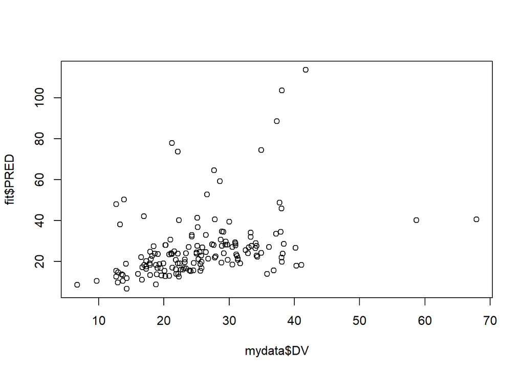

```r
# Estimation of DV: PRED and IPRED

mydata <- pheno_sd[pheno_sd$EVID==0,]
plot(mydata$DV,fit$PRED)
```

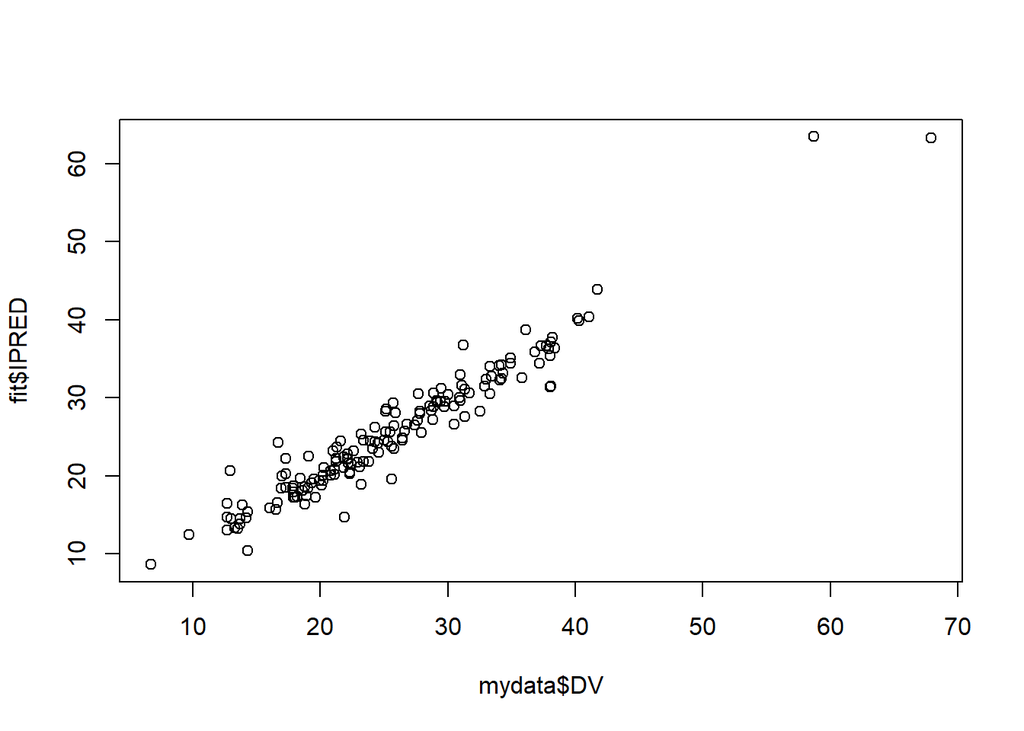

```r
plot(mydata$DV,fit$IPRED)
```

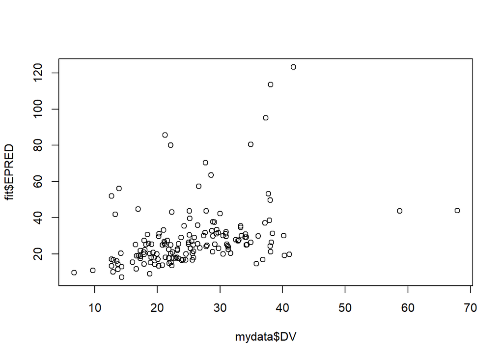

```r
plot(mydata$DV,fit$EPRED)
```

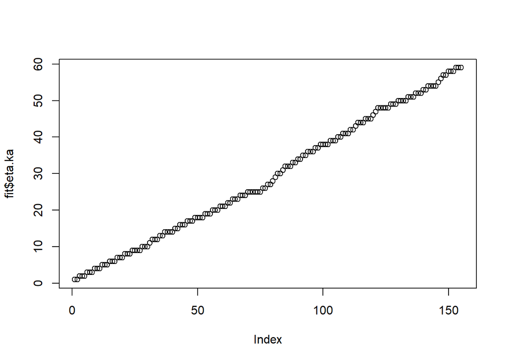

```r
# What is the difference between PRED and IPRED?

# eta.ka:
plot(mydata$ID,fit$eta.ka)
```

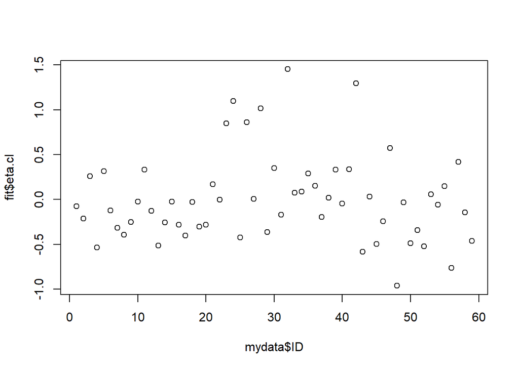

```r
plot(mydata$ID,fit$eta.cl)
```

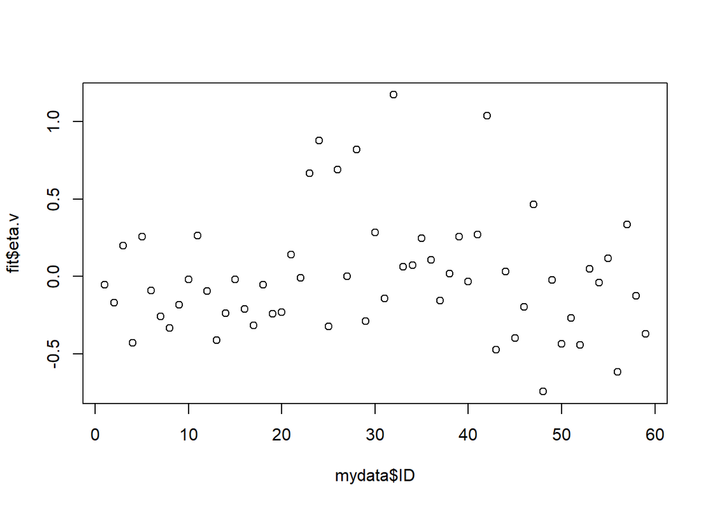

```r
plot(mydata$ID,fit$eta.v)
```

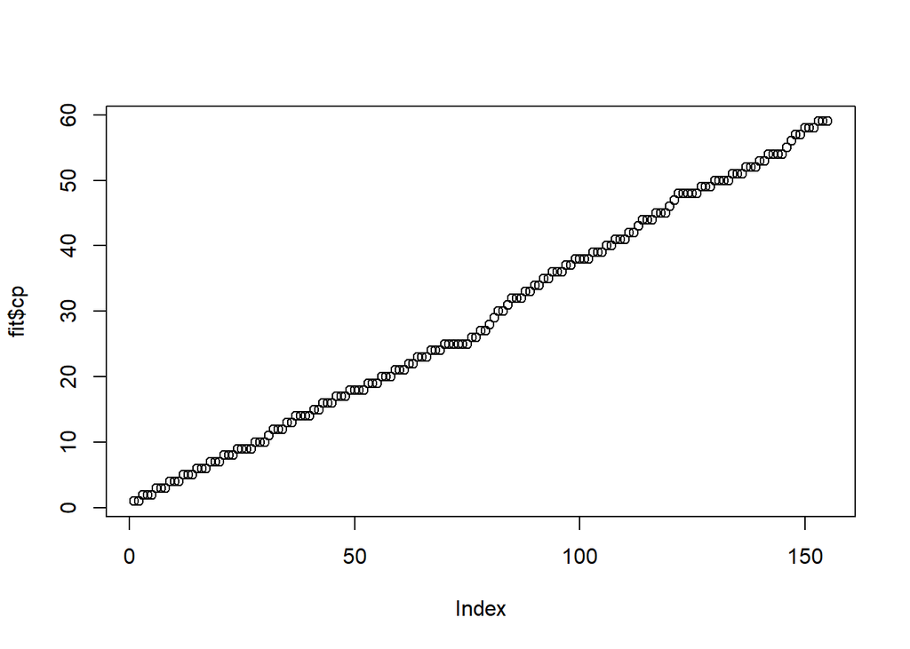

```r
plot(mydata$ID,fit$cp)
```

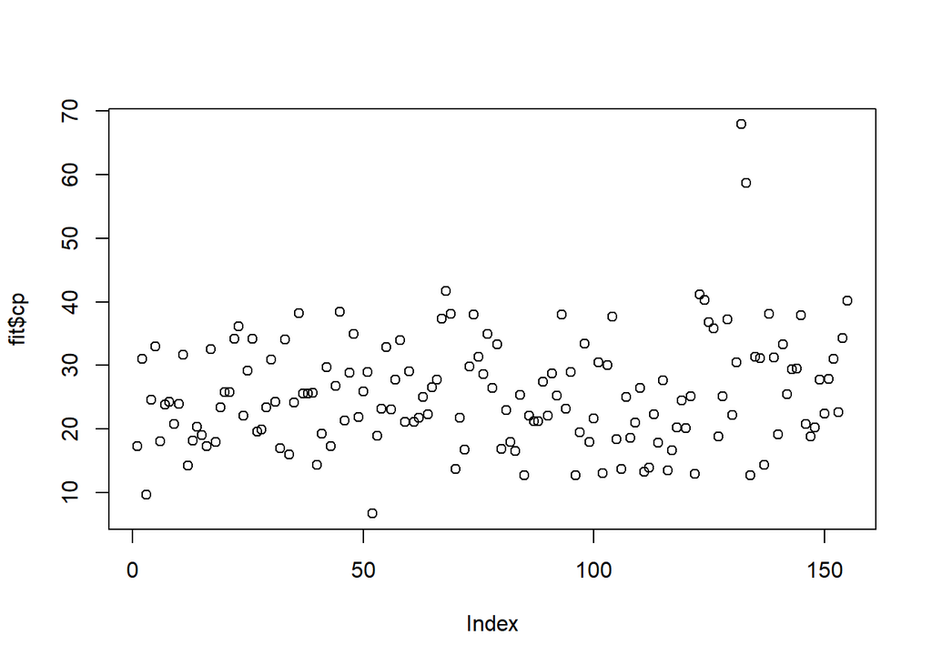

```r
plot(mydata$DV,fit$cp)
```

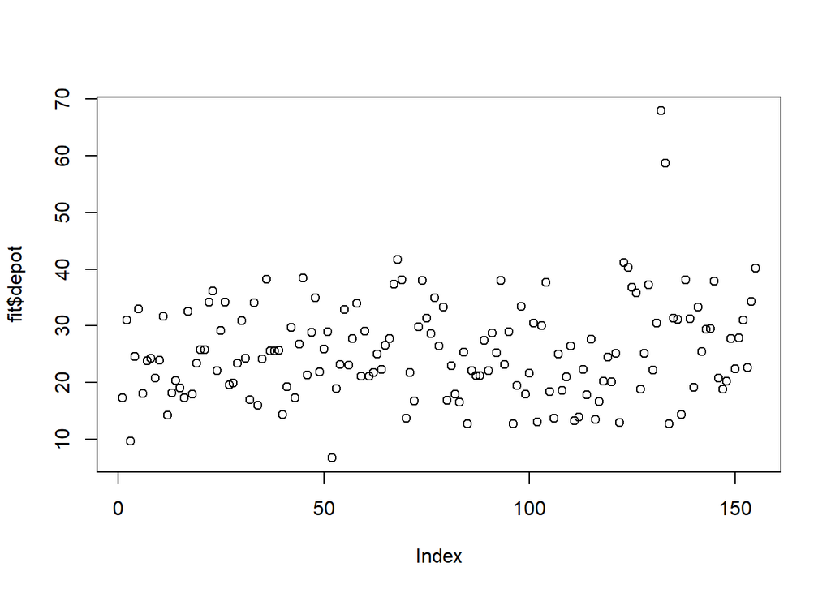

```r
plot(mydata$DV,fit$depot)
```

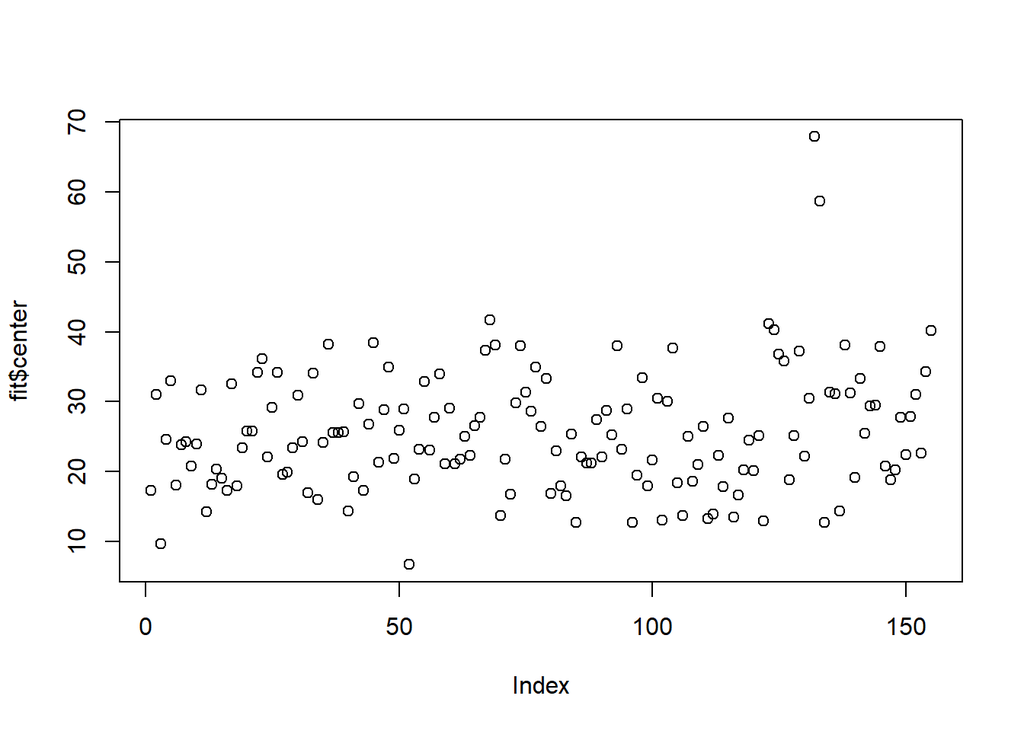

```r
plot(mydata$DV,fit$center)
```

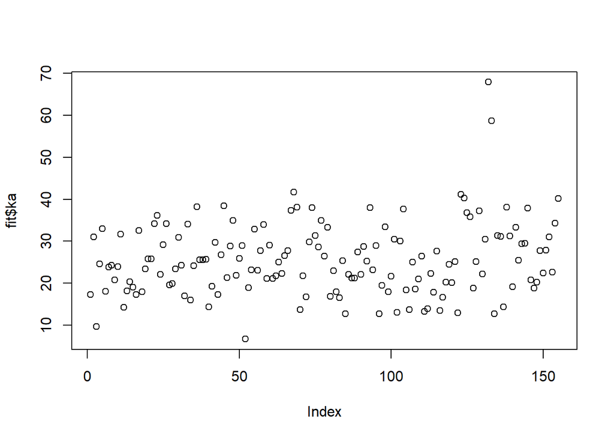

```r
plot(mydata$DV,fit$ka)
```

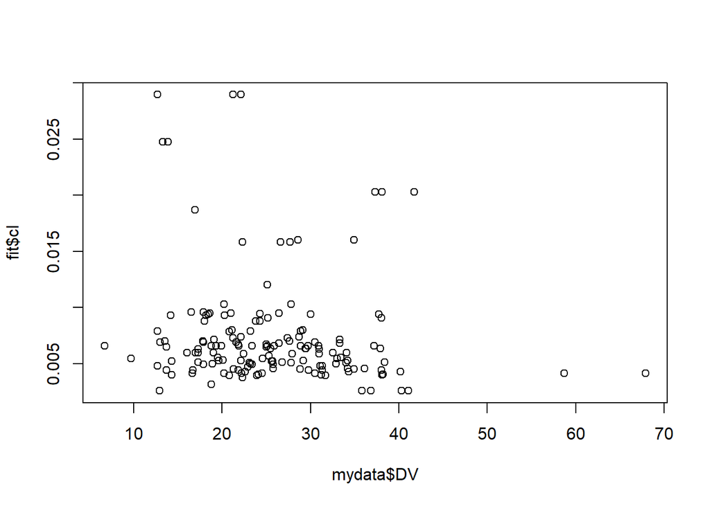

```r
plot(mydata$DV,fit$cl)
```

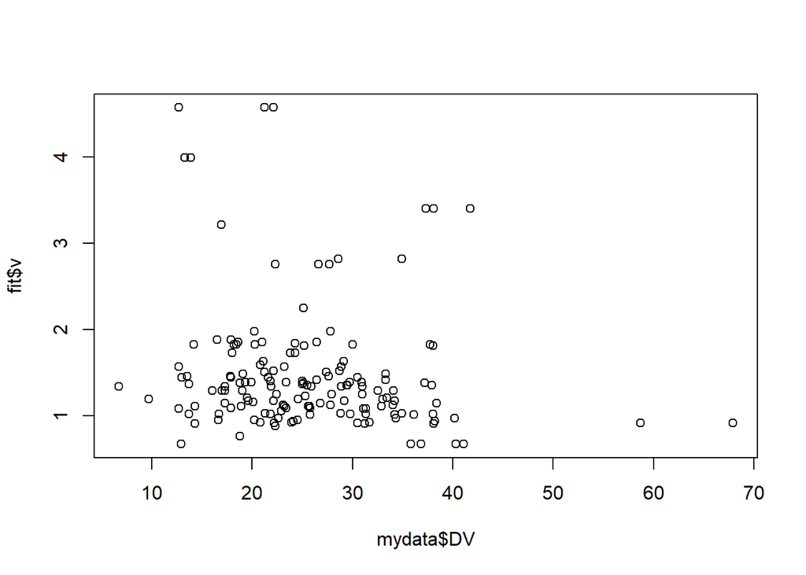

```r
plot(mydata$DV,fit$v)
```

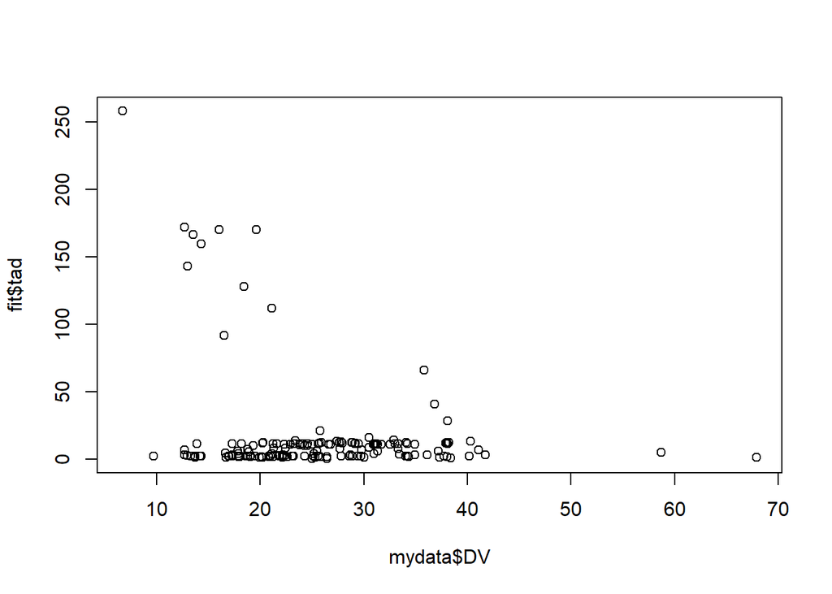

```r
plot(mydata$DV,fit$tad)
```

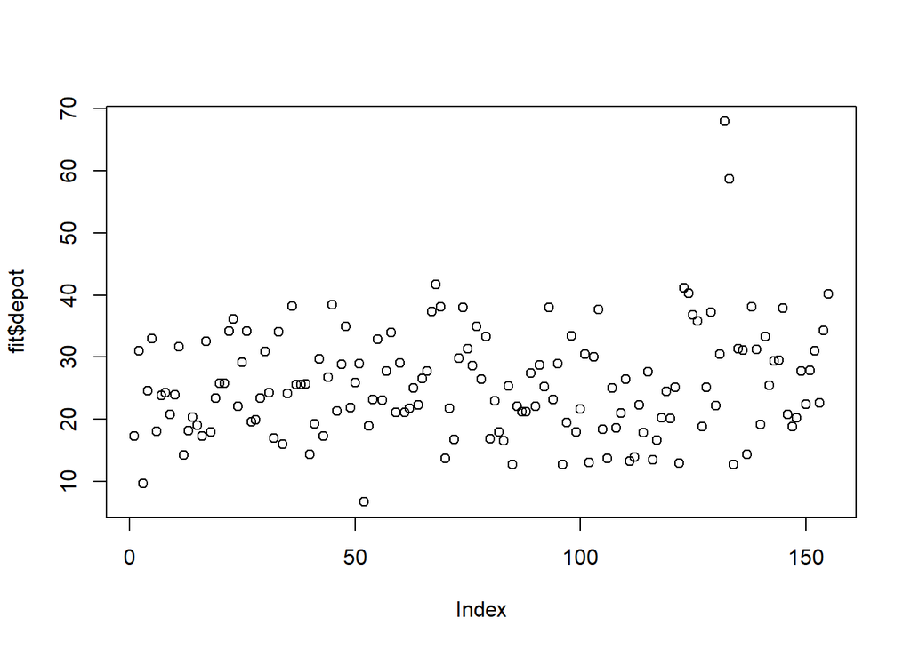

```r
plot(mydata$DV,fit$depot)
```

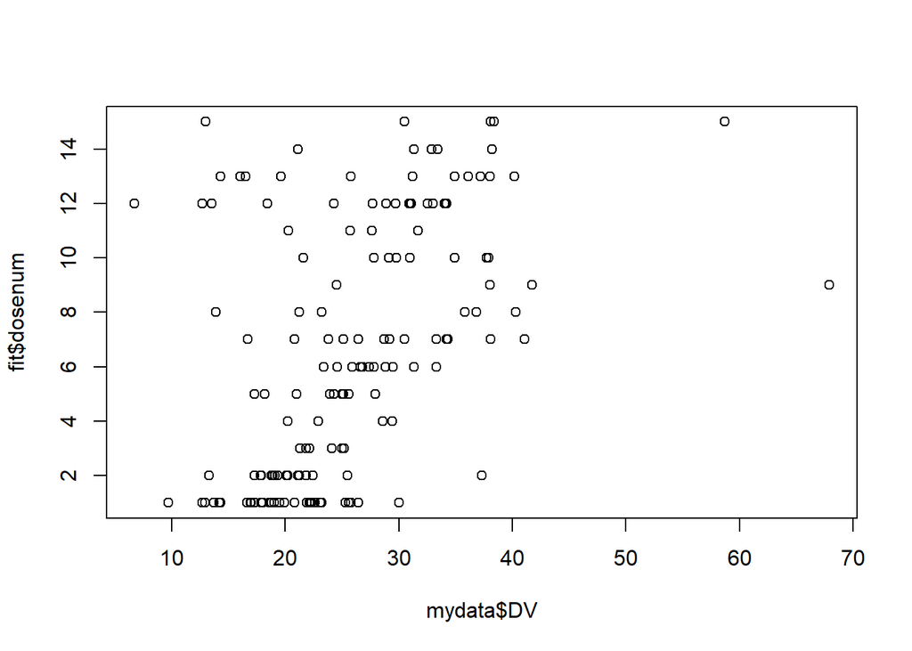

```r
plot(mydata$DV,fit$dosenum)
```

Plots

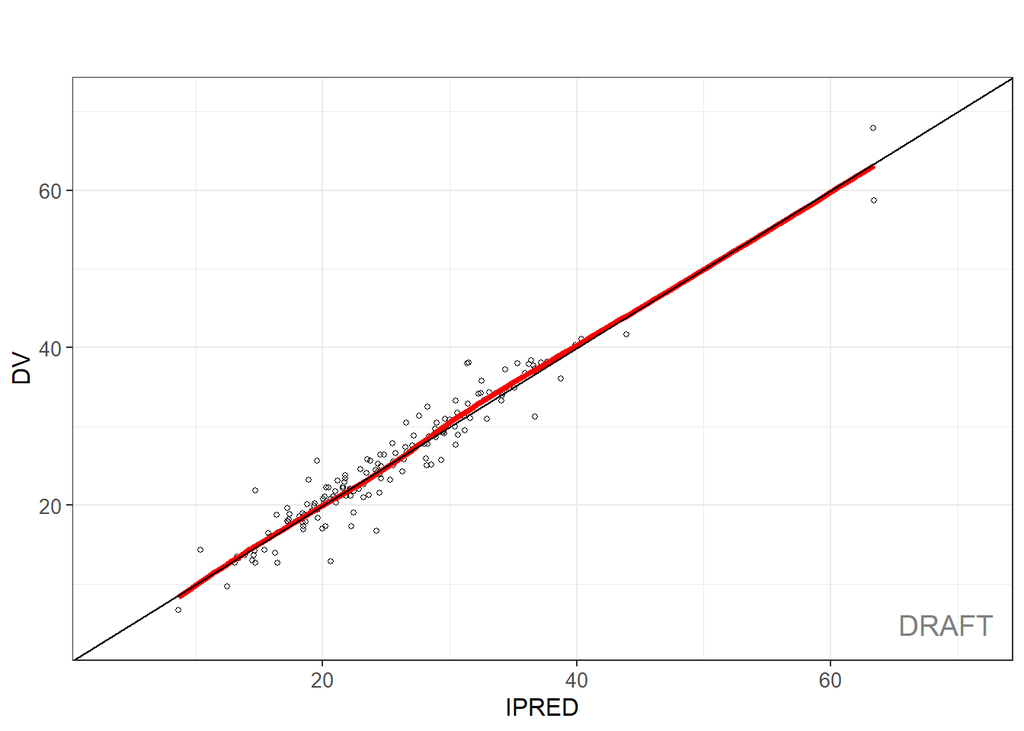

```r
library(xpose.nlmixr2)
xpdb = xpose_data_nlmixr(fit)


library(xpose)
plt <- dv_vs_ipred(xpdb)

library(ggPMX)
ctr = pmx_nlmixr(fit)
pmx_plot_dv_ipred(ctr)
```

Plots